# Лабораторная работы №14. Партиции, файловые системы, монтирование

Презентация

Глушенок А. А.

Российский университет дружбы народов, Москва, Россия

24 октября 2025

## Докладчик

- Глушенок Анна Александровна
- Студент НПИбд-01-24
- Факультет физико-математических и естественных наук
- Российский университет дружбы народов
- 1132246844@pfur.ru
- https://github.com/aaglushenok

## Цель работы

Получить навыки создания разделов на диске и файловых систем. Получить навыки монтирования файловых систем.

## Задание

1. Добавьте два диска на виртуальной машине (раздел 14.4.1).
2. Продемонстрируйте навыки создания разделов MBR с помощью fdisk (раздел 14.4.2).
3. Продемонстрируйте навыки создания логических разделов с помощью fdisk (раз-дел 14.4.3).
4. Продемонстрируйте навыки создания раздела подкачки с помощью fdisk (раз-дел 14.4.4).
5. Продемонстрируйте навыки создания разделов GPT с помощью gdisk (раздел 14.4.5).
6. Продемонстрируйте навыки форматирования файловой системы XFS (раздел 14.4.6).
7. Продемонстрируйте навыки форматирования файловой системы ЕХТ4 (раздел 14.4.7).
8. Продемонстрируйте навыки ручного монтирования файловых систем (раздел 14.4.8).
9. Продемонстрируйте навыки монтирования файловых систем с помощью /etc/fstab (раздел 14.4.9).
10. Выполните задание для самостоятельной работы (раздел 14.5).

# Выполнение лабораторной работы

# Создание виртуальных носителей

## Создание виртуальных носителей

1. Добавьте к вашей виртуальной машине два диска размером 512 МБ (Настроить -> Носители -> на контроллере SATA «Добавить жёсткий диск» -> «Создать образ диска» -> VDI -> «Динамический виртуальный жёсткий диск». Указываем месторасположение диска, размер и название. То же для второго диска.

[figure not shown]

Задание 1

## Создание виртуальных носителей

[figure not shown]

Задание 1

# Создание разделов MBR с помощью fdisk

## Создание разделов MBR с помощью fdisk

1. Запустите виртуальную машину с добавленными дисками disk1 и disk2, с помощью fisk посмотрите перечень разделов на всех имеющихся устройствах жёстких дисков: su - fdisk –list

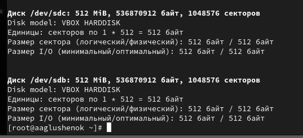

Задание 1

## Создание разделов MBR с помощью fdisk

2. Сделаем разметку диска / dev/sdb с помощью утилиты fdisk: fdisk /dev/sdb. Введите m, чтобы получить справку по командам.

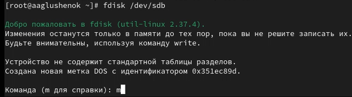

Задание 2

## Создание разделов MBR с помощью fdisk

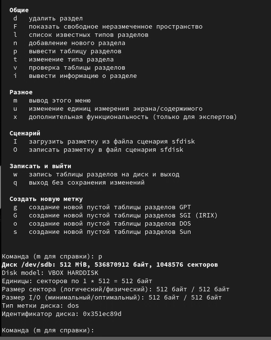

Задание 2

## Создание разделов MBR с помощью fdisk

3. Нажмите p, чтобы просмотреть текущее распределение пространства диска.

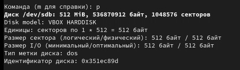

Задание 3

## Создание разделов MBR с помощью fdisk

4. Введите n , чтобы добавить новый раздел. Выберите р , чтобы создать основной раздел. Примите номер раздела, который предлагается. Укажите сектор, с которого начнется новый раздел, нажмите Enter. Укажите последний сектор: введите +100M, чтобы создать раздел на 100 МіВ
5. Нажмите Enter, чтобы принять тип раздела по умолчанию 83. Нажмите w, чтобы записать изменения на диск и выйти из Idisk.

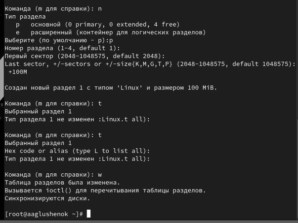

Задание 5

# Создание разделов MBR с помощью fdisk

## Создание разделов MBR с помощью fdisk

6. Сравните вывод команды fdisk -l/dev/sdb с выводом команды cat /proc/partitions. Запишите изменения в таблицу разделов ядра: partprobe /dev/sdb

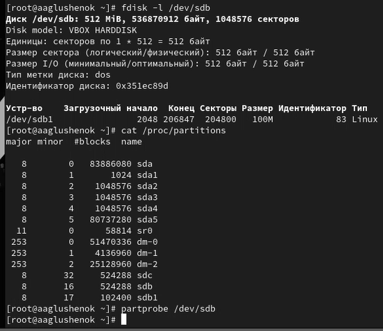

Задание 6

# Создание логических разделов

## Создание логических разделов

1. В терминале с полномочиями администратора запустите fdisk /dev/sdb. Введите п, чтобы добавить новый раздел. Введите е, чтобы создать расширенный раздел. Нажмите Enter, чтобы принять первый сектор по умолчанию и снова нажмите Enter, когда fdisk запросит последний сектор.

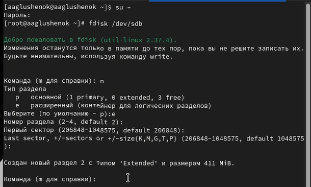

Задание 1

## Создание логических разделов

2. Логический раздел. Из интерфейса fdisk снова нажмите n . Нажмите Enter, чтобы принять выбор первого сектора в качестве сектора по умол-чанию. На вопрос о последнем секторе введите +101М. После создания логического раздела введите w, чтобы записать изменения на диск и выйти из fdisk. Чтобы завершить процедуру и обновить таблицу разделов, введите partprobe /dev/sdb Новый раздел теперь готов к использованию.

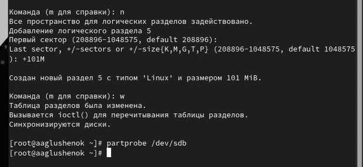

Задание 2

## Создание логических разделов

3. Просмотрите информацию о добавленных разделах: cat /proc/partitions fdisk –list /dev/sdb

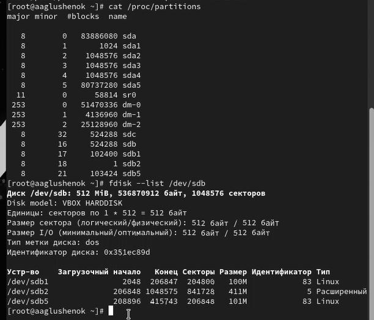

Задание 3

# Создание раздела подкачки

## Создание раздела подкачки

1. Получите полномочия администратора. Запустите fdisk: fdisk /dev/sdb. Нажмите n , чтобы добавить новый раздел. Нажмите Enter, чтобы принять первый сектор по умолчанию. На вопрос о последнем секторе введите +100М. Далее измените тип раздела. Для этого нажмите t , затем укажите номер партиции (6). Затем введите код типа раздела (82 - подкачка). После введите w, чтобы записать изменения на диск и выйти из fdisk. Чтобы завершить процедуру и обновить таблицу разделов ядра, введите partprobe /dev/sdb

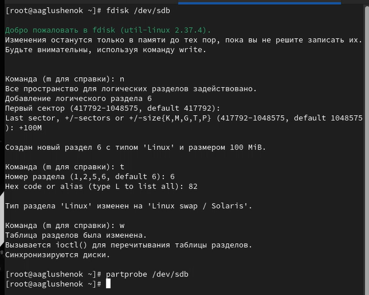

Задание 1

## Создание раздела подкачки

2. Просмотрите информацию о добавленных разделах: cat /proc/partitions fdisk –list /dev/sdb

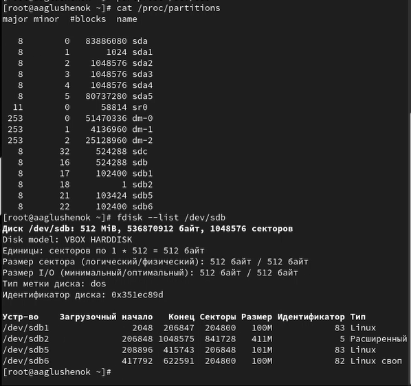

Задание 2

## Создание раздела подкачки

3. Отформатируйте раздел подкачки, используя команду mkswap /dev/sdb6. Для включения вновь выделенного пространства подкачки используйте swapon /dev/sdb6. Для просмотра размера пространства подкачки, которое в настоящее время выделено, введите free -m.

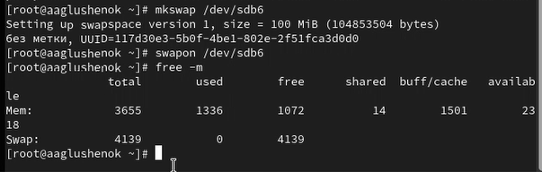

Задание 3

# Создание разделов GPT с помощью gdisk

## Создание разделов GPT с помощью gdisk

1. В терминале с полномочиями администратора с помощью gdisk посмотрите таблицы разделов и разделы на втором добавленном вами ранее диске / dev/sdc: gdisk -l /dev/sdc
2. Создайте раздел с помощью gdisk: gdisk /dev/sdc

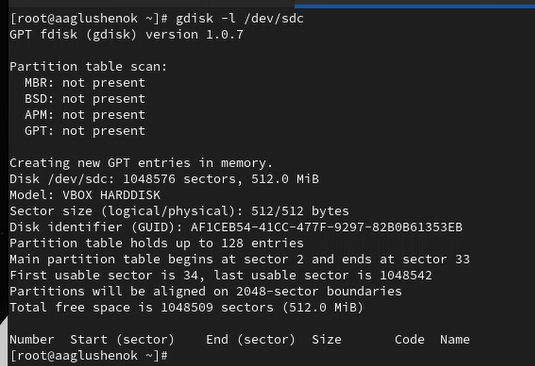

Задание 1-2

## Создание разделов GPT с помощью gdisk

3. Введите n, чтобы добавить новый раздел. Теперь вас попросят задать первый сектор. Нажмите Enter, чтобы принять предлагаемый по умолчанию сектор. При запросе последнего сектора используйте +100М. Теперь предлагается установить тип раздела. Можно просто нажать Enter, чтобы принять тип раздела 8300 по умолчанию. Теперь раздел создан. Нажмите p, чтобы отобразить разбиение диска. Если текущее разбиение устраивает, нажмите w, чтобы записать изменения на диск. Обновите таблицу разделов: partprobe /dev/sde

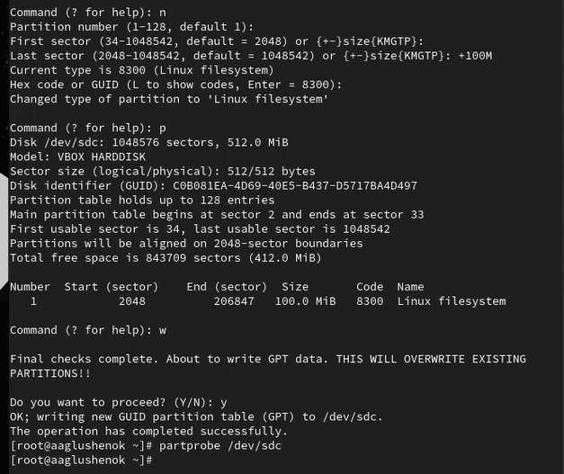

Задание 3

## Создание разделов GPT с помощью gdisk

4. Просмотрите информацию о добавленных разделах: cat /proc/partitions gdisk -l /dev/sde

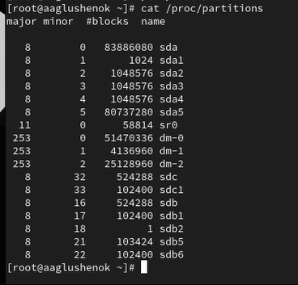

Задание 4

## Создание разделов GPT с помощью gdisk

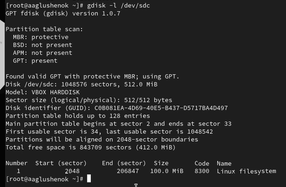

Задание 4

# Форматирование файловой системы XFS

## Форматирование файловой системы XFS

 1. В терминале с полномочиями администратора для диска dev / sdb1 создайте файло-вую систему XFS: mkfs.xfs /dev/sdb1

2. Для установки метки файловой системы в xfsdisk используйте команду xis_admin -L xisdisk /dev/sdb1

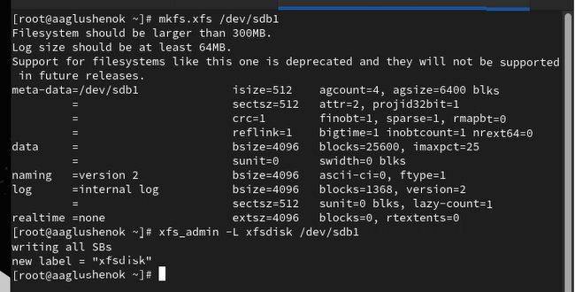

Задание 2

# Форматирование файловой системы EXT4

## Форматирование файловой системы EXT4

1. В терминале с полномочиями администратора для диска dev / sdb5 создайте файло-вую систему EXT4: mkfs.ext4/dev/sdb5
2. Для установки метки файловой системы в ext4di sk используйте команду tune2fs -L ext4disk /dev/sdb5
3. Для установки параметров монтирования по умолчанию для файловой системы ис-пользуйте команду tunelfs -o acl, user_xattr / dev/sdb5

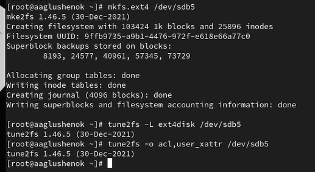

Задание 3

# Ручное монтирование файловых систем

## Ручное монтирование файловых систем

1. Получите полномочия администратора. Для создания точки монтирования для раздела введите mkdir -p/mnt/tmp. Чтобы смонтировать файловую систему, используйте следующую команду mount /dev/sdb5/mnt/tmp. Для проверки корректности монтирования раздела введите: mount. Чтобы отмонтировать раздел: umount /dev/sdb5
2. Проверьте, что раздел отмонтирован: mount

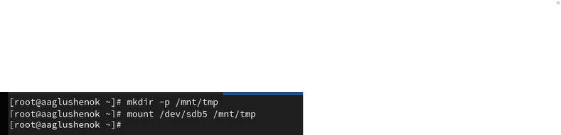

Задание 2

## Ручное монтирование файловых систем

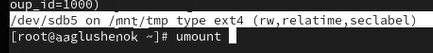

Задание 2

## Ручное монтирование файловых систем

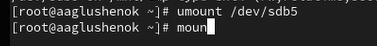

Задание 2

# Монтирование разделов с помощью /etc/fstab

## Монтирование разделов с помощью /etc/fstab

1. Получите полномочия администратора. Создайте точку монтирования для раздела XFS / dev/sdb1: mkdir -p/mnt/data. Посмотрите информацию об идентификаторах блочных устройств (UUID): blkid. Введите blkid /dev/sdb1 и затем используйте мышь, чтобы скопировать значение идентификатора UUID для устройства / dev/sdb1.

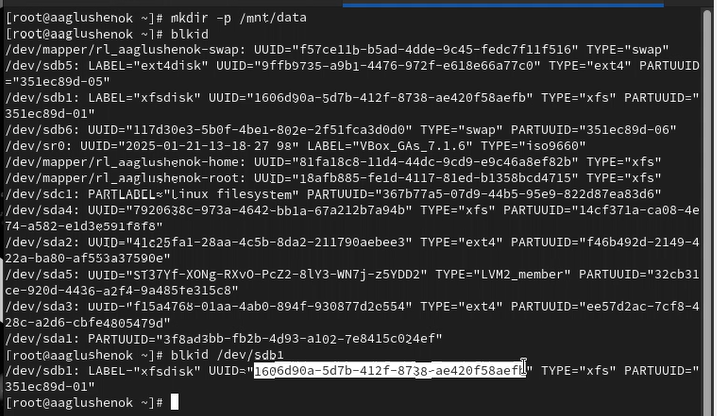

Задание 1

## Монтирование разделов с помощью /etc/fstab

2. Откройте файл / etc/fstab на редактирование и добавьте следующую строку: UUID=значение_идентификатора / mnt/data xfs defaults 1 2

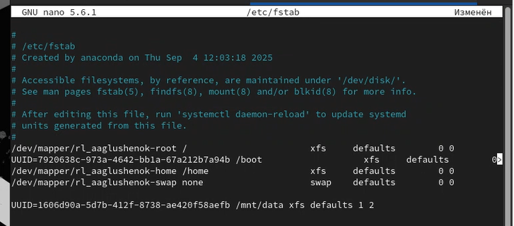

Задание 2

## Монтирование разделов с помощью /etc/fstab

3. Перед попыткой автоматического монтирования при перезагрузке рекомендует-ся проверить конфигурацию. Следующая команда монтирует всё, что указано B/etc/fstab: mount -a. Проверьте, что раздел примонтирован правильно: df -h

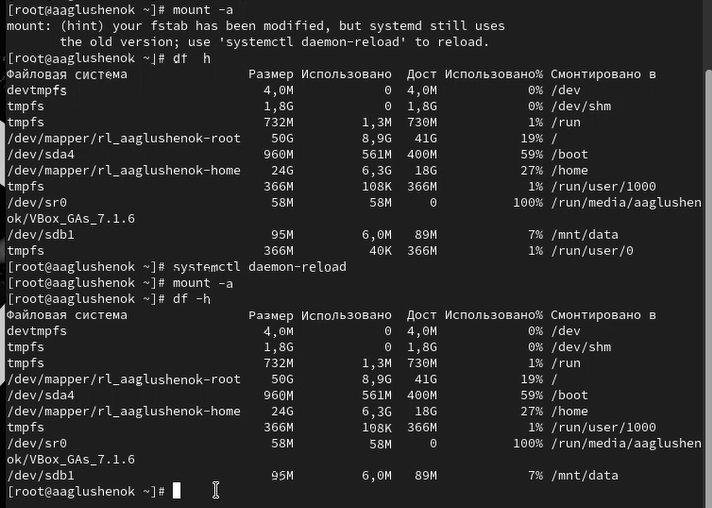

Задание 3

# Вывод

В ходе выполнения лабораторной работы №14 мне удалось получить навыки cоздания разделов на диске и файловых систем. Получить навыки монтирования файловых систем.

# Благодарю за внимание!